```python
import numpy as np
import pandas as pd
import matplotlib.pyplot as plt
import seaborn as sns
sns.set(color_codes=True)
%matplotlib inline
```

# Part One

#### Import data

```python
signal_data = pd.read_csv('Part- 1,2&3 - Signal.csv')
```

#### Data analysis & visualisation

• Perform relevant and detailed statistical analysis on the data.

• Perform relevant and detailed uni, bi and multi variate analysis.

```python
signal_data.head()
```

|  | Parameter 1 | Parameter 2 | Parameter 3 | Parameter 4 | Parameter 5 | Parameter 6 | Parameter 7 | Parameter 8 | Parameter 9 | Parameter 10 | Parameter 11 | Signal_Strength |
| --- | --- | --- | --- | --- | --- | --- | --- | --- | --- | --- | --- | --- |
| 0 | 7.4 | 0.70 | 0.00 | 1.9 | 0.076 | 11.0 | 34.0 | 0.9978 | 3.51 | 0.56 | 9.4 | 5 |
| 1 | 7.8 | 0.88 | 0.00 | 2.6 | 0.098 | 25.0 | 67.0 | 0.9968 | 3.20 | 0.68 | 9.8 | 5 |
| 2 | 7.8 | 0.76 | 0.04 | 2.3 | 0.092 | 15.0 | 54.0 | 0.9970 | 3.26 | 0.65 | 9.8 | 5 |
| 3 | 11.2 | 0.28 | 0.56 | 1.9 | 0.075 | 17.0 | 60.0 | 0.9980 | 3.16 | 0.58 | 9.8 | 6 |
| 4 | 7.4 | 0.70 | 0.00 | 1.9 | 0.076 | 11.0 | 34.0 | 0.9978 | 3.51 | 0.56 | 9.4 | 5 |

```python
print('Shape of Signal DataFrame',signal_data.shape)
print('Size of Signal DataFrame',signal_data.size)
```

```
Shape of Signal DataFrame (1599, 12)
Size of Signal DataFrame 19188
```

###### The data has 12 columns and 1599 rows

###### Signal_Strength is the target column while other 11 columns are independent variables

```python
signal_data["Signal_Strength"].nunique()
```

```
6
```

```python
signal_data.info()
```

```
<class 'pandas.core.frame.DataFrame'>
RangeIndex: 1599 entries, 0 to 1598
Data columns (total 12 columns):
 #   Column           Non-Null Count  Dtype
---  ------           --------------  -----
 0   Parameter 1      1599 non-null   float64
 1   Parameter 2      1599 non-null   float64
 2   Parameter 3      1599 non-null   float64
 3   Parameter 4      1599 non-null   float64
 4   Parameter 5      1599 non-null   float64
 5   Parameter 6      1599 non-null   float64
 6   Parameter 7      1599 non-null   float64
 7   Parameter 8      1599 non-null   float64
 8   Parameter 9      1599 non-null   float64
 9   Parameter 10     1599 non-null   float64
 10  Parameter 11     1599 non-null   float64
 11  Signal_Strength  1599 non-null   int64
dtypes: float64(11), int64(1)
memory usage: 150.0 KB
```

###### Independent 11 columns are of type float and the target column Signal_Strength is integer type has 6 unique values

```python
signal_data.isnull().sum()
```

```
Parameter 1        0
Parameter 2        0
Parameter 3        0
Parameter 4        0
Parameter 5        0
Parameter 6        0
Parameter 7        0
Parameter 8        0
Parameter 9        0
Parameter 10       0
Parameter 11       0
Signal_Strength    0
dtype: int64
```

```python
signal_data.describe(include='all').transpose()
```

|  | count | mean | std | min | 25% | 50% | 75% | max |
| --- | --- | --- | --- | --- | --- | --- | --- | --- |
| Parameter 1 | 1599.0 | 8.319637 | 1.741096 | 4.60000 | 7.1000 | 7.90000 | 9.200000 | 15.90000 |
| Parameter 2 | 1599.0 | 0.527821 | 0.179060 | 0.12000 | 0.3900 | 0.52000 | 0.640000 | 1.58000 |
| Parameter 3 | 1599.0 | 0.270976 | 0.194801 | 0.00000 | 0.0900 | 0.26000 | 0.420000 | 1.00000 |
| Parameter 4 | 1599.0 | 2.538806 | 1.409928 | 0.90000 | 1.9000 | 2.20000 | 2.600000 | 15.50000 |
| Parameter 5 | 1599.0 | 0.087467 | 0.047065 | 0.01200 | 0.0700 | 0.07900 | 0.090000 | 0.61100 |
| Parameter 6 | 1599.0 | 15.874922 | 10.460157 | 1.00000 | 7.0000 | 14.00000 | 21.000000 | 72.00000 |
| Parameter 7 | 1599.0 | 46.467792 | 32.895324 | 6.00000 | 22.0000 | 38.00000 | 62.000000 | 289.00000 |
| Parameter 8 | 1599.0 | 0.996747 | 0.001887 | 0.99007 | 0.9956 | 0.99675 | 0.997835 | 1.00369 |
| Parameter 9 | 1599.0 | 3.311113 | 0.154386 | 2.74000 | 3.2100 | 3.31000 | 3.400000 | 4.01000 |
| Parameter 10 | 1599.0 | 0.658149 | 0.169507 | 0.33000 | 0.5500 | 0.62000 | 0.730000 | 2.00000 |
| Parameter 11 | 1599.0 | 10.422983 | 1.065668 | 8.40000 | 9.5000 | 10.20000 | 11.100000 | 14.90000 |
| Signal_Strength | 1599.0 | 5.636023 | 0.807569 | 3.00000 | 5.0000 | 6.00000 | 6.000000 | 8.00000 |

```python
correlation=signal_data.corr()
correlation
```

|  | Parameter 1 | Parameter 2 | Parameter 3 | Parameter 4 | Parameter 5 | Parameter 6 | Parameter 7 | Parameter 8 | Parameter 9 | Parameter 10 | Parameter 11 | Signal_Strength |
| --- | --- | --- | --- | --- | --- | --- | --- | --- | --- | --- | --- | --- |
| Parameter 1 | 1.000000 | -0.256131 | 0.671703 | 0.114777 | 0.093705 | -0.153794 | -0.113181 | 0.668047 | -0.682978 | 0.183006 | -0.061668 | 0.124052 |
| Parameter 2 | -0.256131 | 1.000000 | -0.552496 | 0.001918 | 0.061298 | -0.010504 | 0.076470 | 0.022026 | 0.234937 | -0.260987 | -0.202288 | -0.390558 |
| Parameter 3 | 0.671703 | -0.552496 | 1.000000 | 0.143577 | 0.203823 | -0.060978 | 0.035533 | 0.364947 | -0.541904 | 0.312770 | 0.109903 | 0.226373 |
| Parameter 4 | 0.114777 | 0.001918 | 0.143577 | 1.000000 | 0.055610 | 0.187049 | 0.203028 | 0.355283 | -0.085652 | 0.005527 | 0.042075 | 0.013732 |
| Parameter 5 | 0.093705 | 0.061298 | 0.203823 | 0.055610 | 1.000000 | 0.005562 | 0.047400 | 0.200632 | -0.265026 | 0.371260 | -0.221141 | -0.128907 |
| Parameter 6 | -0.153794 | -0.010504 | -0.060978 | 0.187049 | 0.005562 | 1.000000 | 0.667666 | -0.021946 | 0.070377 | 0.051658 | -0.069408 | -0.050656 |
| Parameter 7 | -0.113181 | 0.076470 | 0.035533 | 0.203028 | 0.047400 | 0.667666 | 1.000000 | 0.071269 | -0.066495 | 0.042947 | -0.205654 | -0.185100 |
| Parameter 8 | 0.668047 | 0.022026 | 0.364947 | 0.355283 | 0.200632 | -0.021946 | 0.071269 | 1.000000 | -0.341699 | 0.148506 | -0.496180 | -0.174919 |
| Parameter 9 | -0.682978 | 0.234937 | -0.541904 | -0.085652 | -0.265026 | 0.070377 | -0.066495 | -0.341699 | 1.000000 | -0.196648 | 0.205633 | -0.057731 |
| Parameter 10 | 0.183006 | -0.260987 | 0.312770 | 0.005527 | 0.371260 | 0.051658 | 0.042947 | 0.148506 | -0.196648 | 1.000000 | 0.093595 | 0.251397 |
| Parameter 11 | -0.061668 | -0.202288 | 0.109903 | 0.042075 | -0.221141 | -0.069408 | -0.205654 | -0.496180 | 0.205633 | 0.093595 | 1.000000 | 0.476166 |
| Signal_Strength | 0.124052 | -0.390558 | 0.226373 | 0.013732 | -0.128907 | -0.050656 | -0.185100 | -0.174919 | -0.057731 | 0.251397 | 0.476166 | 1.000000 |

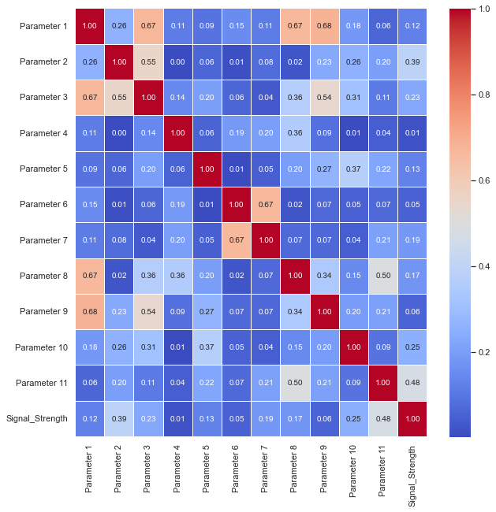

```python
#checking the correlation between the attributes/features
fig,ax = plt.subplots(figsize=(10, 10))
sns.heatmap(signal_data.corr().abs(), ax=ax, annot=True, linewidths=0.05, fmt= '.2f',cmap="coolwarm")
```

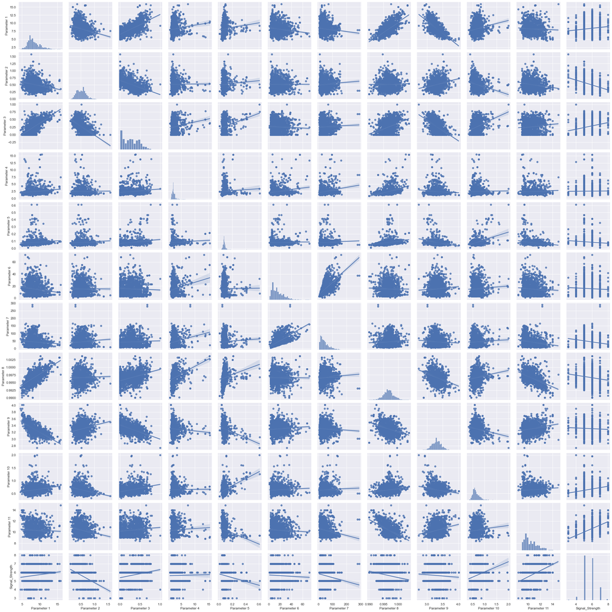

```python
sns.pairplot(signal_data,kind="reg")
```

#### Design, train, tune and test a neural network regressor

```python
# Importing tensorflow and keras libraries
import tensorflow as tf
from tensorflow import keras
from tensorflow.keras import layers
from keras.models import Sequential
from tensorflow.keras import optimizers
from keras.layers import Activation, Dense, LeakyReLU
from keras.layers import Flatten
from IPython.core.interactiveshell import InteractiveShell
InteractiveShell.ast_node_interactivity = "all"
```

```python
# Segregating the independent and target columns and performing a train test split
target = signal_data['Signal_Strength']
df = signal_data.loc[:, signal_data.columns != 'Signal_Strength']
from sklearn.model_selection import train_test_split
X_train, X_test, y_train, y_test = train_test_split(df,target, test_size = 0.3, random_state = 10)
```

```python
# performing standard scaling to remove data skewness and to standarize the values
from sklearn.preprocessing import StandardScaler
from pandas import DataFrame
scaler = StandardScaler()
X_train_scaled = scaler.fit_transform(X_train)
X_test_scaled = scaler.transform(X_test)
```

###### Used standard scaler to tranform and normalize the data

```python
X_train_scaled.shape
```

```
(1119, 11)
```

```python
y_train.shape
```

```
(1119,)
```

```python
X_test_scaled.shape
```

```
(480, 11)
```

```python
y_test.shape
```

```
(480,)
```

```python
regressionModel=Sequential()
regressionModel.add(Dense(128, kernel_initializer='normal',input_dim = X_train.shape[1], activation='relu'))
regressionModel.add(Dense(64, kernel_initializer='normal',activation='relu'))
regressionModel.add(Dense(32, kernel_initializer='normal'))
regressionModel.add(LeakyReLU(alpha=0.1))
regressionModel.add(Dense(16, kernel_initializer='normal'))
regressionModel.add(LeakyReLU(alpha=0.1))
regressionModel.add(Dense(1, kernel_initializer='normal'))
regressionModel.add(LeakyReLU(alpha=0.1))
regressionModel.compile(loss='mean_absolute_error', optimizer='adam', metrics=['mean_squared_error'])
regressionModel.summary()
```

```
Model: "sequential"
_________________________________________________________________
Layer (type)                 Output Shape              Param #
=================================================================
dense (Dense)                (None, 128)               1536
_________________________________________________________________
dense_1 (Dense)              (None, 64)                8256
_________________________________________________________________
dense_2 (Dense)              (None, 32)                2080
_________________________________________________________________
leaky_re_lu (LeakyReLU)      (None, 32)                0
_________________________________________________________________
dense_3 (Dense)              (None, 16)                528
_________________________________________________________________
leaky_re_lu_1 (LeakyReLU)    (None, 16)                0
_________________________________________________________________
dense_4 (Dense)              (None, 1)                 17
_________________________________________________________________
leaky_re_lu_2 (LeakyReLU)    (None, 1)                 0
=================================================================
Total params: 12,417
Trainable params: 12,417
Non-trainable params: 0
_________________________________________________________________
```

```python
# Regression model with performance metrics as mean squared error on unscaled data
NN_Regressor = regressionModel.fit(X_train, y_train,validation_data=(X_test,y_test),batch_size = 100, epochs = 100, verbose = 1)
```

```python
# Evaluating the model on the test data
results = regressionModel.evaluate(X_test, y_test)
```

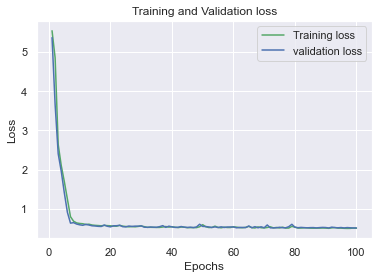

```python
loss_train = NN_Regressor.history['loss']
loss_val = NN_Regressor.history['val_loss']
epochs = range(1,101)
plt.plot(epochs, loss_train, 'g', label='Training loss');
plt.plot(epochs, loss_val, 'b', label='validation loss');
plt.title('Training and Validation loss');
plt.xlabel('Epochs');
plt.ylabel('Loss');
plt.legend();
plt.show();
```

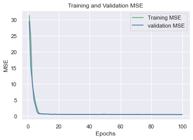

```python
MSE_train = NN_Regressor.history['mean_squared_error']
MSE_val = NN_Regressor.history['val_mean_squared_error']
epochs = range(1,101)
plt.plot(epochs, MSE_train, 'g', label='Training MSE');
plt.plot(epochs, MSE_val, 'b', label='validation MSE');
plt.title('Training and Validation MSE');
plt.xlabel('Epochs');
plt.ylabel('MSE');
plt.legend();
plt.show();
```

#### Lets run the model on scaled data and see if we see any improvement in the MSE

```python
NN_Regressor_scaled = regressionModel.fit(X_train_scaled, y_train, validation_data=(X_test_scaled,y_test), batch_size = 10, epochs = 100, verbose = 1)
```

```python
results_scaled = regressionModel.evaluate(X_test_scaled, y_test)
```

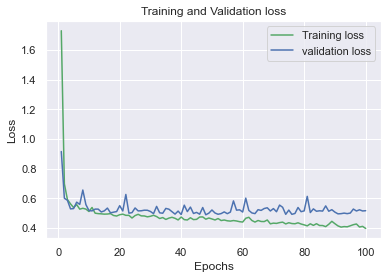

```python
loss_train = NN_Regressor_scaled.history['loss']
loss_val = NN_Regressor_scaled.history['val_loss']
epochs = range(1,101)
plt.plot(epochs, loss_train, 'g', label='Training loss');
plt.plot(epochs, loss_val, 'b', label='validation loss');
plt.title('Training and Validation loss');
plt.xlabel('Epochs');
plt.ylabel('Loss');
plt.legend();
plt.show();
```

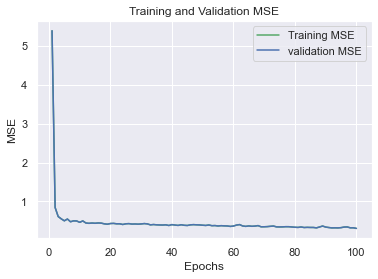

```python
MSE_train = NN_Regressor_scaled.history['mean_squared_error']
MSE_val = NN_Regressor_scaled.history['mean_squared_error']
epochs = range(1,101)
plt.plot(epochs, MSE_train, 'g', label='Training MSE');
plt.plot(epochs, MSE_val, 'b', label='validation MSE');
plt.title('Training and Validation MSE');
plt.xlabel('Epochs');
plt.ylabel('MSE');
plt.legend();
plt.show();
```

#### Pickling the model

```python
# Saving the model to disk
def pickleModel(model, model_file_name):
    model.save(model_file_name)
    print("Saved model to disk")
```

```python
pickleModel(regressionModel,"regressionSignalModel.h5")
```

```
Saved model to disk
```

```python
# load and evaluate a saved model
from numpy import loadtxt
from tensorflow.keras.models import load_model
# load model
model = load_model('regressionSignalModel.h5')
# summarize model.
model.summary()
# load dataset
X = X_test_scaled
Y = y_test
# evaluate the model
score = model.evaluate(X, Y, verbose=0)
print(model.metrics_names[1],":", round(score[1],2))
```

```
Model: "sequential"
_________________________________________________________________
Layer (type)                 Output Shape              Param #
=================================================================
dense (Dense)                (None, 128)               1536
_________________________________________________________________
dense_1 (Dense)              (None, 64)                8256
_________________________________________________________________
dense_2 (Dense)              (None, 32)                2080
_________________________________________________________________
leaky_re_lu (LeakyReLU)      (None, 32)                0
_________________________________________________________________
dense_3 (Dense)              (None, 16)                528
_________________________________________________________________
leaky_re_lu_1 (LeakyReLU)    (None, 16)                0
_________________________________________________________________
dense_4 (Dense)              (None, 1)                 17
_________________________________________________________________
leaky_re_lu_2 (LeakyReLU)    (None, 1)                 0
=================================================================
Total params: 12,417
Trainable params: 12,417
Non-trainable params: 0
_________________________________________________________________
mean_squared_error : 0.46
```

# Part Two

```python
# Convering the target column to categorical data type
from tensorflow.keras.utils import to_categorical
y_cat_train = to_categorical(y_train)
y_cat_test = to_categorical(y_test)
print(y_cat_test[1].shape)
```

```
(9,)
```

```python
classifierModel=Sequential()
classifierModel.add(Dense(128, kernel_initializer='normal',input_dim = X_train.shape[1], activation='relu'))
classifierModel.add(Dense(64, kernel_initializer='normal',activation='relu'))
classifierModel.add(Dense(32, kernel_initializer='normal'))
classifierModel.add(LeakyReLU(alpha=0.1))
classifierModel.add(Dense(16, kernel_initializer='normal'))
classifierModel.add(LeakyReLU(alpha=0.1))
classifierModel.add(Dense(9, kernel_initializer='normal',activation='softmax'))
classifierModel.compile(loss='mean_absolute_error', optimizer='adam', metrics=['accuracy'])
classifierModel.summary()
```

```
Model: "sequential_1"
_________________________________________________________________
Layer (type)                 Output Shape              Param #
=================================================================
dense_5 (Dense)              (None, 128)               1536
_________________________________________________________________
dense_6 (Dense)              (None, 64)                8256
_________________________________________________________________
dense_7 (Dense)              (None, 32)                2080
_________________________________________________________________
leaky_re_lu_3 (LeakyReLU)    (None, 32)                0
_________________________________________________________________
dense_8 (Dense)              (None, 16)                528
_________________________________________________________________
leaky_re_lu_4 (LeakyReLU)    (None, 16)                0
_________________________________________________________________
dense_9 (Dense)              (None, 9)                 153
=================================================================
Total params: 12,553
Trainable params: 12,553
Non-trainable params: 0
_________________________________________________________________
```

```python
NN_Classifier = classifierModel.fit(X_train_scaled, y_cat_train, validation_data=(X_test_scaled,y_cat_test), batch_size = 10, epochs=200)
```

```python
pred_train= classifierModel.predict(X_train)
scores = classifierModel.evaluate(X_train, y_cat_train, verbose=0)
print('Accuracy on training data: {}% \n Error on training data: {}'.format(scores[1], 1 - scores[1]))

pred_test= classifierModel.predict(X_test)
scores2 = classifierModel.evaluate(X_test, y_cat_test, verbose=0)
print('Accuracy on test data: {}% \n Error on test data: {}'.format(scores2[1], 1 - scores2[1]))
```

```
Accuracy on training data: 0.4584450423717499%
 Error on training data: 0.5415549576282501
Accuracy on test data: 0.44999998807907104%
 Error on test data: 0.550000011920929
```

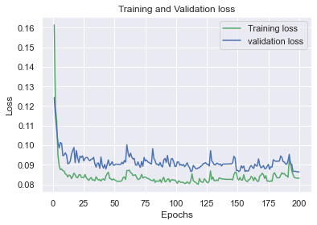

```python
loss_train = NN_Classifier.history['loss']
loss_val = NN_Classifier.history['val_loss']
epochs = range(1,201)
plt.plot(epochs, loss_train, 'g', label='Training loss');
plt.plot(epochs, loss_val, 'b', label='validation loss');
plt.title('Training and Validation loss');
plt.xlabel('Epochs');
plt.ylabel('Loss');
plt.legend();
plt.show();
```

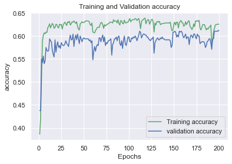

```python
Acc_train = NN_Classifier.history['accuracy']
Acc_val = NN_Classifier.history['val_accuracy']
epochs = range(1,201)
plt.plot(epochs, Acc_train, 'g', label='Training accuracy');
plt.plot(epochs, Acc_val, 'b', label='validation accuracy');
plt.title('Training and Validation accuracy');
plt.xlabel('Epochs');
plt.ylabel('accuracy');
plt.legend();
plt.show();
```

###### Trying dropout and batch normalization to reduce overfitting and improve accuracy

```python
from keras.models import Sequential
from keras.layers import BatchNormalization, Dropout
```

```python
classifierDropoutModel=Sequential()
classifierDropoutModel.add(Dense(50, input_dim = X_train.shape[1] , kernel_initializer='he_normal'))
classifierDropoutModel.add(BatchNormalization())
classifierDropoutModel.add(Activation('relu'))
classifierDropoutModel.add(Dropout(0.2))
classifierDropoutModel.add(Dense(50, kernel_initializer='he_normal'))
classifierDropoutModel.add(BatchNormalization())
classifierDropoutModel.add(Activation('relu'))
classifierDropoutModel.add(Dropout(0.2))
classifierDropoutModel.add(Dense(50, kernel_initializer='he_normal'))
classifierDropoutModel.add(BatchNormalization())
classifierDropoutModel.add(Activation('relu'))
classifierDropoutModel.add(Dropout(0.2))
classifierDropoutModel.add(Dense(9, kernel_initializer='he_normal'))
classifierDropoutModel.add(Activation('softmax'))

adam = optimizers.Adam(lr = 0.001)
classifierDropoutModel.compile(optimizer = adam, loss = 'categorical_crossentropy', metrics = ['accuracy'])
```

```python
classifierDropoutModel.summary()
```

```
Model: "sequential_2"
_________________________________________________________________
Layer (type)                 Output Shape              Param #
=================================================================
dense_10 (Dense)             (None, 50)                600
_________________________________________________________________
batch_normalization (BatchNo (None, 50)                200
_________________________________________________________________
activation (Activation)      (None, 50)                0
_________________________________________________________________
dropout (Dropout)            (None, 50)                0
_________________________________________________________________
dense_11 (Dense)             (None, 50)                2550
_________________________________________________________________
batch_normalization_1 (Batch (None, 50)                200
_________________________________________________________________
activation_1 (Activation)    (None, 50)                0
_________________________________________________________________
dropout_1 (Dropout)          (None, 50)                0
_________________________________________________________________
dense_12 (Dense)             (None, 50)                2550
_________________________________________________________________
batch_normalization_2 (Batch (None, 50)                200
_________________________________________________________________
activation_2 (Activation)    (None, 50)                0
_________________________________________________________________
dropout_2 (Dropout)          (None, 50)                0
_________________________________________________________________
dense_13 (Dense)             (None, 9)                 459
_________________________________________________________________
activation_3 (Activation)    (None, 9)                 0
=================================================================
Total params: 6,759
Trainable params: 6,459
Non-trainable params: 300
_________________________________________________________________
```

```python
NN_Dropout_Classifier = classifierDropoutModel.fit(X_train_scaled, y_cat_train, validation_data=(X_test_scaled,y_cat_test), batch_size = 10, epochs=200)
```

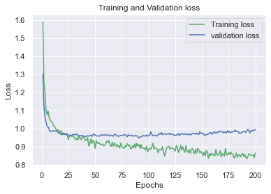

```python
loss_train = NN_Dropout_Classifier.history['loss']
loss_val = NN_Dropout_Classifier.history['val_loss']
epochs = range(1,201)
plt.plot(epochs, loss_train, 'g', label='Training loss');
plt.plot(epochs, loss_val, 'b', label='validation loss');
plt.title('Training and Validation loss');
plt.xlabel('Epochs');
plt.ylabel('Loss');
plt.legend();
plt.show();
```

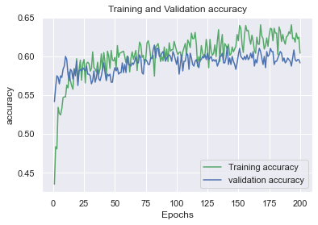

```python
Acc_train = NN_Dropout_Classifier.history['accuracy']
Acc_val = NN_Dropout_Classifier.history['val_accuracy']
epochs = range(1,201)
plt.plot(epochs, Acc_train, 'g', label='Training accuracy');
plt.plot(epochs, Acc_val, 'b', label='validation accuracy');
plt.title('Training and Validation accuracy');
plt.xlabel('Epochs');
plt.ylabel('accuracy');
plt.legend();
plt.show();
```

#### Pickling the model

```python
pickleModel(classifierDropoutModel,"categoricalSignalModel.h5")
```

```
Saved model to disk
```

```python
# load and evaluate a saved model
from numpy import loadtxt
from tensorflow.keras.models import load_model
# load model
model = load_model('categoricalSignalModel.h5')
# summarize model.
model.summary()
# load dataset
X = X_test_scaled
Y = y_cat_test
# evaluate the model
score = model.evaluate(X, Y, verbose=0)
print("%s: %.2f%%" % (model.metrics_names[1], score[1]*100))
```

```
Model: "sequential_2"
_________________________________________________________________
Layer (type)                 Output Shape              Param #
=================================================================
dense_10 (Dense)             (None, 50)                600
_________________________________________________________________
batch_normalization (BatchNo (None, 50)                200
_________________________________________________________________
activation (Activation)      (None, 50)                0
_________________________________________________________________
dropout (Dropout)            (None, 50)                0
_________________________________________________________________
dense_11 (Dense)             (None, 50)                2550
_________________________________________________________________
batch_normalization_1 (Batch (None, 50)                200
_________________________________________________________________
activation_1 (Activation)    (None, 50)                0
_________________________________________________________________
dropout_1 (Dropout)          (None, 50)                0
_________________________________________________________________
dense_12 (Dense)             (None, 50)                2550
_________________________________________________________________
batch_normalization_2 (Batch (None, 50)                200
_________________________________________________________________
activation_2 (Activation)    (None, 50)                0
_________________________________________________________________
dropout_2 (Dropout)          (None, 50)                0
_________________________________________________________________
dense_13 (Dense)             (None, 9)                 459
_________________________________________________________________
activation_3 (Activation)    (None, 9)                 0
=================================================================
Total params: 6,759
Trainable params: 6,459
Non-trainable params: 300
_________________________________________________________________
accuracy: 59.17%
```

# Part Three

```python
import tkinter as tk;
from tkinter import ttk;
import pandas as pd;
import re;

##App window
win= tk.Tk();
win.title('Neural Networks GUI - Great Learning');


##-------------------------Step1----------
Name= ttk.Label(win,text="Step1:File Name")
Name.grid(row=0,column=0,sticky=tk.W)

Name_var= tk.StringVar();
Name_entrybox= ttk.Entry(win,width=16,textvariable=Name_var)
Name_entrybox.grid(row=0,column=1)

def importData():
    global df
    DF_Name= Name_var.get()
    DB_extension=re.findall("\..*",DF_Name)
    if DB_extension==['.csv']:
        df=pd.read_csv(DF_Name);
    confirm="Done"
    confirm_entrybox= ttk.Entry(win,width=16)
    confirm_entrybox.grid(row=0,column=3)
    confirm_entrybox.insert(1,str(confirm))

importDataButton = ttk.Button(win, text="Import Data", command= importData)
importDataButton.grid(row=0,column=2)

##-------------------------Step2----------
Target= ttk.Label(win,text="Step2:Target Column")
Target.grid(row=1,column=0,sticky=tk.W)

Target_var= tk.StringVar();
Target_entrybox= ttk.Entry(win,width=16,textvariable=Target_var)
Target_entrybox.grid(row=1,column=1)

def checkTarget():
    global TARGET
    target_Name= Target_var.get()
    if target_Name in df.columns:
        TARGET= df[target_Name]
        confirm="Found"
        confirm_entrybox= ttk.Entry(win,width=16)
        confirm_entrybox.grid(row=1,column=3)
        confirm_entrybox.insert(1,str(confirm))



importTargetButton = ttk.Button(win, text="Import Target", command= checkTarget)
importTargetButton.grid(row=1,column=2)


##-------------------------Step3----------
def trainModel():
    global regModel
    regModel=regressionModel;
    confirm_entrybox= ttk.Entry(win,width=25)
    confirm_entrybox.grid(row=4,column=2)
    try:
        regModel.fit(X_train, y_train, epochs = 200, verbose = 1)
        confirm="Network Trained"
        confirm_entrybox.insert(1,str(confirm))
    except:
        confirm="Exception occured"
        confirm_entrybox.insert(1,str(confirm))

def runModel():
    scores1= regModel.evaluate(X_test, y_test,  verbose=1)
    print('Accuracy of regression model on test data: {}% \n Error on test data: {}'.format(scores1[1], 1 - scores1[1]))
    pickleModel(regModel, "regression_signal_GUI.h5")
    confirm="Saved Model to disk"
    confirm_entrybox= ttk.Entry(win,width=25)
    confirm_entrybox.grid(row=5,column=2)
    confirm_entrybox.insert(1,str(confirm))


NNRegressionLabel= ttk.Label(win,text="Step3: Neural Network Regressor")
NNRegressionLabel.grid(row=3,column=0,sticky=tk.W)


RegressionLabel= ttk.Label(win,text="Regression")
RegressionLabel.grid(row=4,column=0,sticky=tk.E)

trainButton = ttk.Button(win, text="Train", command= trainModel)
trainButton.grid(row=4,column=1)


PickleLabel= ttk.Label(win,text="Pickle")
PickleLabel.grid(row=5,column=0,sticky=tk.E)

runButton = ttk.Button(win, text="Run", command= runModel)
runButton.grid(row=5,column=1)


##-------------------------Step4----------

def trainClassifierModel():
    global classificationModel
    classificationModel=classifierDropoutModel;
    confirm_entrybox= ttk.Entry(win,width=25)
    confirm_entrybox.grid(row=7,column=2)
    try:
        classificationModel.fit(X_train_scaled, y_cat_train, epochs = 200, verbose = 1)
        confirm="Network Trained"
        confirm_entrybox.insert(1,str(confirm))
    except:
        confirm="Exception occured"
        confirm_entrybox.insert(1,str(confirm))

def runClassifierModel():
    scores2=classificationModel.evaluate(X_test_scaled, y_cat_test,  verbose = 1)
    print('Accuracy of categorical model on test data: {}% \n Error on test data: {}'.format(scores2[1], 1 - scores2[1]))
    pickleModel(classificationModel, "classification_GUI.h5")
    confirm="Saved Model to disk"
    confirm_entrybox= ttk.Entry(win,width=25)
    confirm_entrybox.grid(row=8,column=2)
    confirm_entrybox.insert(1,str(confirm))

NNclassifierLabel= ttk.Label(win,text="Step4: Neural Network Classifier")
NNclassifierLabel.grid(row=6,column=0,sticky=tk.W)

classifierLabel= ttk.Label(win,text="Classifier")
classifierLabel.grid(row=7,column=0,sticky=tk.E)

trainButton = ttk.Button(win, text="Train", command= trainClassifierModel)
trainButton.grid(row=7,column=1)

runButton = ttk.Button(win, text="Run", command= runClassifierModel)
runButton.grid(row=8,column=1)


# start the GUI
win.mainloop()
```

```
''
```

# Part 4

#### Import the data

```python
import h5py
dataset =h5py.File('Part - 4 - Autonomous_Vehicles_SVHN_single_grey1.h5','r')
```

```python
dataset.keys()
```

```
<KeysViewHDF5 ['X_test', 'X_train', 'X_val', 'y_test', 'y_train', 'y_val']>
```

```python
dataset['X_train']
```

```
<HDF5 dataset "X_train": shape (42000, 32, 32), type "<f4">
```

```python
X_train = dataset["X_train"][:]
y_train = dataset["y_train"][:]
X_test=dataset["X_test"][:]
y_test = dataset["y_test"][:]
X_val = dataset["X_val"][:]
y_val = dataset["y_val"][:]
```

#### Data pre-processing and visualisation

```
Label: 7
```

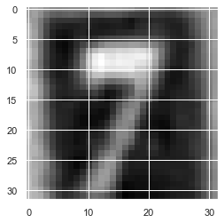

```python
import matplotlib.pyplot as plt
%matplotlib inline
print("Label: {}".format(y_train[2]))
plt.imshow(X_train[2], cmap='gray')
```

```
Label: 5
```

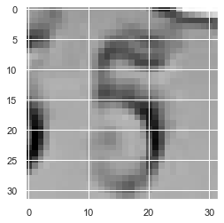

```python
import matplotlib.pyplot as plt
%matplotlib inline
print("Label: {}".format(y_test[22]))
plt.imshow(X_test[22], cmap='gray')
```

```
Label: 0
```

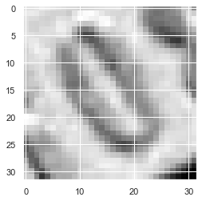

```python
import matplotlib.pyplot as plt
%matplotlib inline
print("Label: {}".format(y_val[10]))
plt.imshow(X_val[10], cmap='gray')
```

```python
print(X_train.shape)
print(y_train.shape)
print(X_test.shape)
print(y_test.shape)
print(X_val.shape)
print(y_val.shape)
```

```
(42000, 32, 32)
(42000,)
(18000, 32, 32)
(18000,)
(60000, 32, 32)
(60000,)
```

###### The training set has 42000 rows, 18000 rows in test and 60000 rows in validation dataset

```python
# Reshaping the dataset to reduce the 3 d to 2 dimensions
arr =np.array(dataset["X_train"][:])
arr=arr.reshape(42000, 1024)
arr
```

```
array([[ 33.0704,  30.2601,  26.852 , ...,  49.6682,  50.853 ,  53.0377],
       [ 86.9591,  87.0685,  88.3735, ...,  75.2206,  76.6396,  79.2865],
       [123.125 , 125.8581, 122.0757, ...,  93.9349, 104.7875, 113.8252],
       ...,
       [154.094 , 155.8057, 156.8164, ..., 135.1328, 136.6596, 137.6595],
       [207.4954, 208.4953, 213.0218, ..., 214.1357, 212.1359, 209.1362],
       [ 95.0784,  96.0783, 100.0779, ..., 138.0803, 140.493 , 140.493 ]],
      dtype=float32)
```

```python
X_train = X_train.reshape(42000, 1024)
print(X_train.shape)
X_test = X_test.reshape(18000, 1024)
print(X_test.shape)
X_val = X_val.reshape(60000, 1024)
print(X_val.shape)
```

```
(42000, 1024)
(18000, 1024)
(60000, 1024)
```

```python
# Converting y data into categorical (one-hot encoding)
y_train = to_categorical(y_train)
y_test = to_categorical(y_test)
y_val = to_categorical(y_val)
```

```python
print(X_test.max())
print(X_test.min())

X_train = X_train / 255.0

print(X_train.max())
print(X_train.min())
```

```
254.9745
0.0
0.9999
0.0
```

```python
print(X_test.max())
print(X_test.min())

X_test = X_test / 255.0

print(X_test.max())
print(X_test.min())
```

```
254.9745
0.0
0.9999
0.0
```

```python
print(X_val.max())
print(X_val.min())

X_val = X_val / 255.0

print(X_val.max())
print(X_val.min())
```

```
254.9745
0.0
0.9999
0.0
```

```python
print(X_train.shape, X_test.shape, X_val.shape, y_train.shape, y_test.shape,  y_val.shape)
```

```
(42000, 1024) (18000, 1024) (60000, 1024) (42000, 10) (18000, 10) (60000, 10)
```

```python
X_train[1].shape
```

```
(1024,)
```

```
label for each of the below image: 2
label for each of the below image: 6
label for each of the below image: 7
label for each of the below image: 4
label for each of the below image: 4
label for each of the below image: 0
label for each of the below image: 3
label for each of the below image: 0
label for each of the below image: 7
label for each of the below image: 3
```

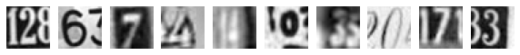

```python
import numpy as np

# visualizing the first 10 images in the dataset and their labels
%matplotlib inline
import matplotlib.pyplot as plt
plt.figure(figsize=(10, 1));
for i in range(10):
    plt.subplot(1, 10, i+1);
    plt.imshow(X_train[i].reshape(32, 32), cmap="gray");
    plt.axis('off');
    print('label for each of the below image: %s' % (np.argmax(y_train[0:10][i])));
plt.show();
```

#### Design, train, tune and test a neural network image classifier

###### Defining the sequential model with different tunable paramters as input

```python
from tensorflow.keras.models import Sequential
from tensorflow.keras.layers import Dense
from tensorflow.keras import regularizers, optimizers

def train_and_test_loop(iterations, lr, Lambda, verb=True):

    # hyperparameters
    iterations = iterations
    learning_rate = lr
    hidden_nodes = 256
    output_nodes = 10

    model = Sequential()
    model.add(Dense(hidden_nodes, input_shape=(1024,), activation='relu'))
    model.add(Dense(hidden_nodes, activation='relu'))
    model.add(Dense(output_nodes, activation='softmax', kernel_regularizer=regularizers.l2(Lambda)))

    sgd = optimizers.SGD(lr=learning_rate, decay=1e-6, momentum=0.9)
    # Compile model
    model.compile(loss='categorical_crossentropy', optimizer=sgd, metrics=['accuracy'])

    # Fit the model
    model.fit(X_train, y_train, epochs=iterations, batch_size=1000, verbose= 1)
    return model
```

```python
def train_and_test_loop1(iterations, lr, Lambda, verb=True):

    # hyperparameters
    iterations = iterations
    learning_rate = lr
    hidden_nodes = 256
    output_nodes = 10

    model = Sequential()
    model.add(Dense(hidden_nodes, input_shape=(1024,), activation='relu'))
    model.add(Dense(hidden_nodes, activation='relu'))
    model.add(Dense(output_nodes, activation='softmax', kernel_regularizer=regularizers.l2(Lambda)))

    sgd = optimizers.SGD(lr=learning_rate, decay=1e-6, momentum=0.9)
    # Compile model
    model.compile(loss='categorical_crossentropy', optimizer=sgd, metrics=['accuracy'])

    # Fit the model
    model.fit(X_train, y_train, epochs=iterations, batch_size=1000, verbose= 1)
    score = model.evaluate(X_train, y_train, verbose=0)

    return score
```

```python
lr = 0.00001
Lambda = 0
train_and_test_loop(1, lr, Lambda)
```

```
<keras.engine.sequential.Sequential at 0x25c39a09460>
```

```python
lr = 0.00001
Lambda = 1e3
train_and_test_loop(1, lr, Lambda)
```

```
<keras.engine.sequential.Sequential at 0x25c8cb0ed30>
```

###### Using the sub data to train the parameters

```python
X_train_subset = X_train[0:20]
y_train_subset = y_train[0:20]
```

```python
X_train = X_train_subset
y_train = y_train_subset
```

```python
X_train.shape
```

```
(20, 1024)
```

```python
y_train.shape
```

```
(20, 10)
```

```python
lr = 0.001
Lambda = 0
train_and_test_loop(500, lr, Lambda)
```

```
<keras.engine.sequential.Sequential at 0x25c8e003c10>
```

```python
train_and_test_loop
```

```
<function __main__.train_and_test_loop(iterations, lr, Lambda, verb=True)>
```

```python
X_train = dataset["X_train"][:]
y_train = dataset["y_train"][:]
X_test=dataset["X_test"][:]
y_test = dataset["y_test"][:]
X_val = dataset["X_val"][:]
y_val = dataset["y_val"][:]
```

```python
X_train = X_train.reshape(42000, 1024)
print(X_train.shape)
X_test = X_test.reshape(18000, 1024)
print(X_test.shape)
X_val = X_val.reshape(60000, 1024)
print(X_val.shape)
```

```
(42000, 1024)
(18000, 1024)
(60000, 1024)
```

```python
# Converting y data into categorical (one-hot encoding)
y_train = to_categorical(y_train)
y_test = to_categorical(y_test)
y_val = to_categorical(y_val)
```

```python
X_train = X_train / 255.0
X_test = X_test / 255.0
X_val = X_val / 255.0
```

```python
lr = 1e-7
Lambda = 1e-7
train_and_test_loop(20, lr, Lambda)
```

```
<keras.engine.sequential.Sequential at 0x25c8e539d60>
```

```python
lr = 1e8
Lambda = 1e-7
train_and_test_loop(20, lr, Lambda)
```

```
<keras.engine.sequential.Sequential at 0x25c873e3340>
```

```python
lr = 0.001
Lambda = 1e-3
model = train_and_test_loop(100, lr, Lambda)
```

```python
model.evaluate(X_test,y_test)
```

```
[1.4385700225830078, 0.6078333258628845]
```

```python
model.evaluate(X_val,y_val)
```

```
[1.4399923086166382, 0.6043833494186401]
```

###### The model is giving 60% accuracy on the trainand test data set and giving 60% accuarcy on validation data set as well

##### Automating the process of finding the best value of the parameter for the model

```python
import math

best_accuracy = 0
best_lr = 0
best_Lambda = 0

for k in range(1,10):
    lr = math.pow(10, np.random.uniform(-3.0, 3.0))
    Lambda = math.pow(10, np.random.uniform(-7,-2))
    best_acc = train_and_test_loop1(100, lr, Lambda, False)
    print("Try {0}/{1}: Best_val_acc: {2}, lr: {3}, Lambda: {4}\n".format(k, 9, best_acc[1], lr, Lambda))
    if (best_acc[1]>best_accuracy) :
        best_accuracy = best_acc[1]
        best_lr = lr
        best_Lambda = Lambda

print('\n\nBest parameters of the model :')
print('LR :', best_lr)
print('Lambda :', best_Lambda)
print('Accuracy :', best_accuracy)
```

```
Try 1/9: Best_val_acc: 0.09992857277393341, lr: 78.96529892094622, Lambda: 0.0003471019379203898

Try 2/9: Best_val_acc: 0.09971428662538528, lr: 42.608285175507895, Lambda: 0.0015499201350434638

Try 3/9: Best_val_acc: 0.09966666996479034, lr: 54.74042919748243, Lambda: 0.0003335637842473294

Try 4/9: Best_val_acc: 0.7245714068412781, lr: 0.0021826728917130585, Lambda: 6.994437493153946e-07

Try 5/9: Best_val_acc: 0.8999761939048767, lr: 0.07173358241124893, Lambda: 4.4677164904787464e-07

Try 6/9: Best_val_acc: 0.09971428662538528, lr: 15.583356001571833, Lambda: 0.002405578057654366

Try 7/9: Best_val_acc: 0.09966666996479034, lr: 0.6520715932410812, Lambda: 2.7960092088957174e-05

Try 8/9: Best_val_acc: 0.09966666996479034, lr: 64.64580458822988, Lambda: 0.00028312809310164933

Try 9/9: Best_val_acc: 0.10076190531253815, lr: 1.626813620722225, Lambda: 0.00040421022627757855



Best parameters of the model :
LR : 0.07173358241124893
Lambda : 4.4677164904787464e-07
Accuracy : 0.8999761939048767
```

```python
def train_and_test_loop2(iterations, lr, Lambda, verb=True):

    # hyperparameters
    iterations = iterations
    learning_rate = lr
    hidden_nodes = 256
    output_nodes = 10

    model = Sequential()
    model.add(Dense(hidden_nodes, input_shape=(1024,), activation='relu'))
    model.add(Dense(hidden_nodes, activation='relu'))
    model.add(Dense(output_nodes, activation='softmax', kernel_regularizer=regularizers.l2(Lambda)))

    sgd = optimizers.SGD(lr=learning_rate, decay=1e-6, momentum=0.9)
    # Compile model
    model.compile(loss='categorical_crossentropy', optimizer=sgd, metrics=['accuracy'])

    # Fit the model
    history = model.fit(X_train, y_train, epochs=iterations, batch_size=1000, verbose= 1 , validation_data=(X_val, y_val))
    return history

best_model = train_and_test_loop2(100, best_lr, best_Lambda)
```

```python
best_model.history.keys()
```

```
dict_keys(['loss', 'accuracy', 'val_loss', 'val_accuracy'])
```

#### Plot the training loss, validation loss vs number of epochs and training accuracy, validation accuracy vs number of epochs plot and write your observations on the same

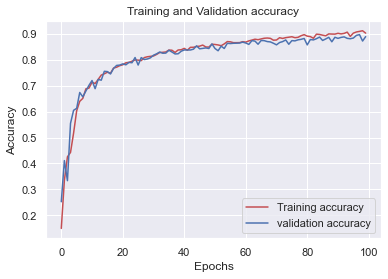

```python
# Visualize loss history
import matplotlib.pyplot as plt
accuracy_train = best_model.history['accuracy']
accuracy_val = best_model.history['val_accuracy']
plt.plot(accuracy_train, 'r', label='Training accuracy');
plt.plot(accuracy_val, 'b', label='validation accuracy');
plt.title('Training and Validation accuracy');
plt.xlabel('Epochs');
plt.ylabel('Accuracy');
plt.legend();
plt.show();
```

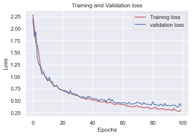

```python
# Visualize loss history
import matplotlib.pyplot as plt
loss_train = best_model.history['loss']
loss_val = best_model.history['val_loss']
plt.plot(loss_train, 'r', label='Training loss');
plt.plot(loss_val, 'b', label='validation loss');
plt.title('Training and Validation loss');
plt.xlabel('Epochs');
plt.ylabel('Loss');
plt.legend();
plt.show();
```

##### Observations

We see that the model is giving very good accuracy on the train and validation data set. Also from the graph it is clear that the loss and the accuracy on the train and validation dataset is similar which shows that the model have similar performance on the train and validataion dataset. The parameters such as lr and Lambda are identified by automating the process of finding the best values for the same.